# Heart-Disease Prediction

FINAL PROJECT Team 1 Mythili Rajaram, Abhishek Tegginamat

# Introduction

This dataset has been picked up from kaggle. In this dataset, our goal is to predict the presence or absence of Heart-Disease using the a few visualizations. We built a Logistic Regression Model to predict our result and also Cross validated the results. In our dataset, the “target” area corresponds to the patient’s existence of heart disease. It has an integer value between 0 (no presence) and 1 (presence) and is stored in the target column. The dependent variable is the target, and the rest of the variables are the independent variables. As we are analyzing the clinical dataset, the following variables are used in our analysis.

**Variables**

- age: The person’s age in years
- sex: The person’s sex (1 = male, 0 = female)
- cp: The chest pain experienced (Value 1: typical angina, Value 2: atypical angina, Value 3: non-anginal pain, Value 4: asymptomatic)
- trestbps: The person’s resting blood pressure (mm Hg on admission to the hospital)
- chol: The person’s cholesterol measurement in mg/dl
- fbs: The person’s fasting blood sugar (if > 120 mg/dl, 1 = true; 0 = false)
- restecg: Resting electrocardiographic measurement (0 = normal, 1 = having ST-T wave abnormality, 2 = showing probable or definite left ventricular hypertrophy by Estes’ criteria)
- thalach: The person’s maximum heart rate achieved
- exang: Exercise induced angina (1 = yes; 0 = no)
- oldpeak: ST depression induced by exercise relative to rest (‘ST’ relates to positions on the ECG plot)
- slope: the slope of the peak exercise ST segment (Value 1: upsloping, Value 2: flat, Value 3: downsloping)
- ca: The number of major vessels (0-3) colored by flourosopy
- thal: A blood disorder called thalassemia (1 = normal; 2 = fixed defect; 3 = reversable defect)
- target: Heart disease (0 = no, 1 = yes)

```r
library(DataExplorer)
library(data.table)
library(dplyr)
library(car)
library(psych)
library(caret)
library(rpart)
library(gridExtra)
library(ROCR)
library(broom)
library("tidyverse")
library("corrplot")
```

```r
str(heart)
```

```
'data.frame':   303 obs. of  14 variables:
 $ age     : int  63 37 41 56 57 57 56 44 52 57 ...
 $ sex     : int  1 1 0 1 0 1 0 1 1 1 ...
 $ cp      : int  3 2 1 1 0 0 1 1 2 2 ...
 $ trestbps: int  145 130 130 120 120 140 140 120 172 150 ...
 $ chol    : int  233 250 204 236 354 192 294 263 199 168 ...
 $ fbs     : int  1 0 0 0 0 0 0 0 1 0 ...
 $ restecg : int  0 1 0 1 1 1 0 1 1 1 ...
 $ thalach : int  150 187 172 178 163 148 153 173 162 174 ...
 $ exang   : int  0 0 0 0 1 0 0 0 0 0 ...
 $ oldpeak : num  2.3 3.5 1.4 0.8 0.6 0.4 1.3 0 0.5 1.6 ...
 $ slope   : int  0 0 2 2 2 1 1 2 2 2 ...
 $ ca      : int  0 0 0 0 0 0 0 0 0 0 ...
 $ thal    : int  1 2 2 2 2 1 2 3 3 2 ...
 $ target  : int  1 1 1 1 1 1 1 1 1 1 ...
```

```r
##Converting categorical variables to factor variables
heart1 <- copy(heart)
heart1$sex <- factor(heart1$sex)
heart1$cp <- factor(heart1$cp)
heart1$fbs <- factor(heart1$fbs)
heart1$restecg <- factor(heart1$restecg)
heart1$exang <- factor(heart1$exang)
heart1$ca <- factor(heart1$ca)
heart1$thal <- factor(heart1$thal)
heart1$target <- factor(heart1$target)

describe(heart1)
```

|  | vars | n | mean | sd | median | trimmed | mad | min | max | range | skew | kurtosis | se |
| --- | --- | --- | --- | --- | --- | --- | --- | --- | --- | --- | --- | --- | --- |
| age | 1 | 303 | 54.37 | 9.08 | 55.0 | 54.54 | 10.38 | 29 | 77.0 | 48.0 | -0.20 | -0.57 | 0.52 |
| sex* | 2 | 303 | 1.68 | 0.47 | 2.0 | 1.73 | 0.00 | 1 | 2.0 | 1.0 | -0.78 | -1.39 | 0.03 |
| cp* | 3 | 303 | 1.97 | 1.03 | 2.0 | 1.86 | 1.48 | 1 | 4.0 | 3.0 | 0.48 | -1.21 | 0.06 |
| trestbps | 4 | 303 | 131.62 | 17.54 | 130.0 | 130.44 | 14.83 | 94 | 200.0 | 106.0 | 0.71 | 0.87 | 1.01 |
| chol | 5 | 303 | 246.26 | 51.83 | 240.0 | 243.49 | 47.44 | 126 | 564.0 | 438.0 | 1.13 | 4.36 | 2.98 |
| fbs* | 6 | 303 | 1.15 | 0.36 | 1.0 | 1.06 | 0.00 | 1 | 2.0 | 1.0 | 1.97 | 1.88 | 0.02 |
| restecg* | 7 | 303 | 1.53 | 0.53 | 2.0 | 1.52 | 0.00 | 1 | 3.0 | 2.0 | 0.16 | -1.37 | 0.03 |
| thalach | 8 | 303 | 149.65 | 22.91 | 153.0 | 150.98 | 22.24 | 71 | 202.0 | 131.0 | -0.53 | -0.10 | 1.32 |
| exang* | 9 | 303 | 1.33 | 0.47 | 1.0 | 1.28 | 0.00 | 1 | 2.0 | 1.0 | 0.74 | -1.46 | 0.03 |
| oldpeak | 10 | 303 | 1.04 | 1.16 | 0.8 | 0.86 | 1.19 | 0 | 6.2 | 6.2 | 1.26 | 1.50 | 0.07 |

[output cut: 4 more lines]

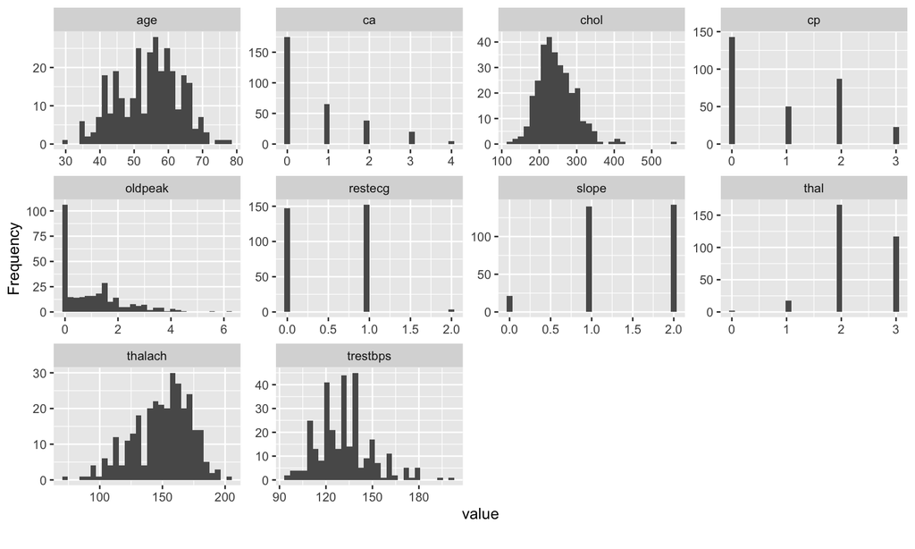

```r
plot_histogram(heart)
```

From the above plot we see that cholesterol, age, and maximum heart rate follow a normal distribution.

# Simple Exploratory Data Analysis

**Heart-disease versus Sex(1 = male; 0 = female)**

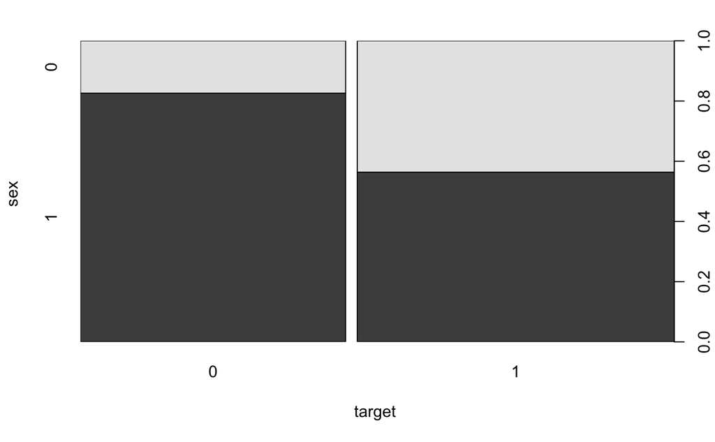

```r
attach(heart1)
plot(target, sex,
   xlab="target ", ylab="sex ", pch=19)
```

**Heart-disease versus Fasting blood sugar > 120 mg/dl (1 = true; 0 = false)**

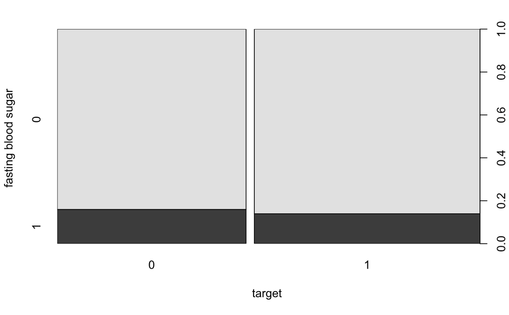

```r
plot(target, fbs,
   xlab="target ", ylab="fasting blood sugar ", pch=19)
```

**Heart-disease versus Resting electrocardiographic results**

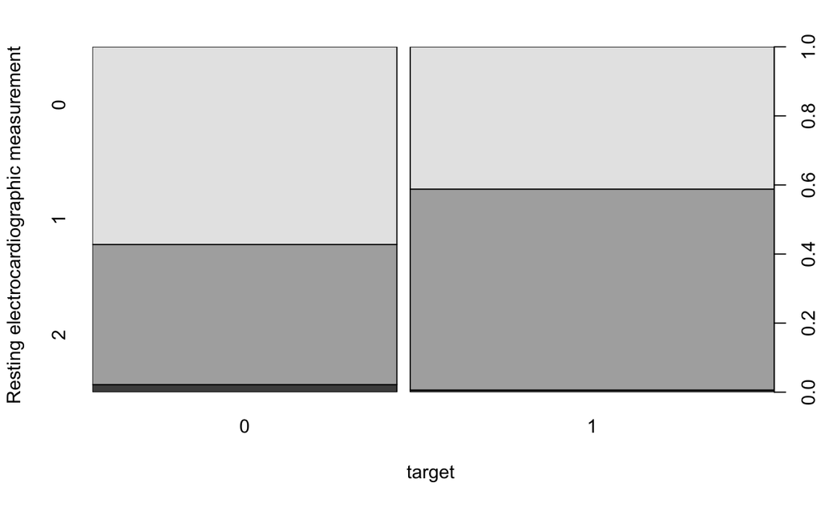

```r
plot(target,restecg,
   xlab="target ", ylab="Resting electrocardiographic measurement  ", pch=19)
```

**Heart-disease versus Exercise induced angina (1 = yes; 0 = no)**

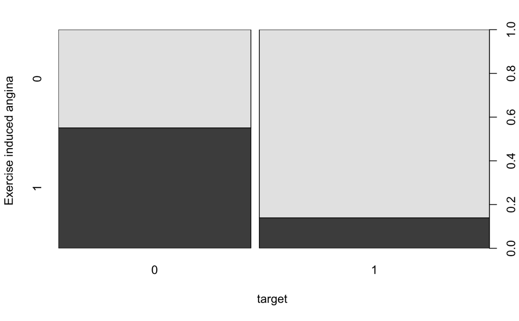

```r
plot(target,exang,
   xlab="target ", ylab="Exercise induced angina ", pch=19)
```

**Heart-disease versus Number of major vessels (0-3) colored by flourosopy**

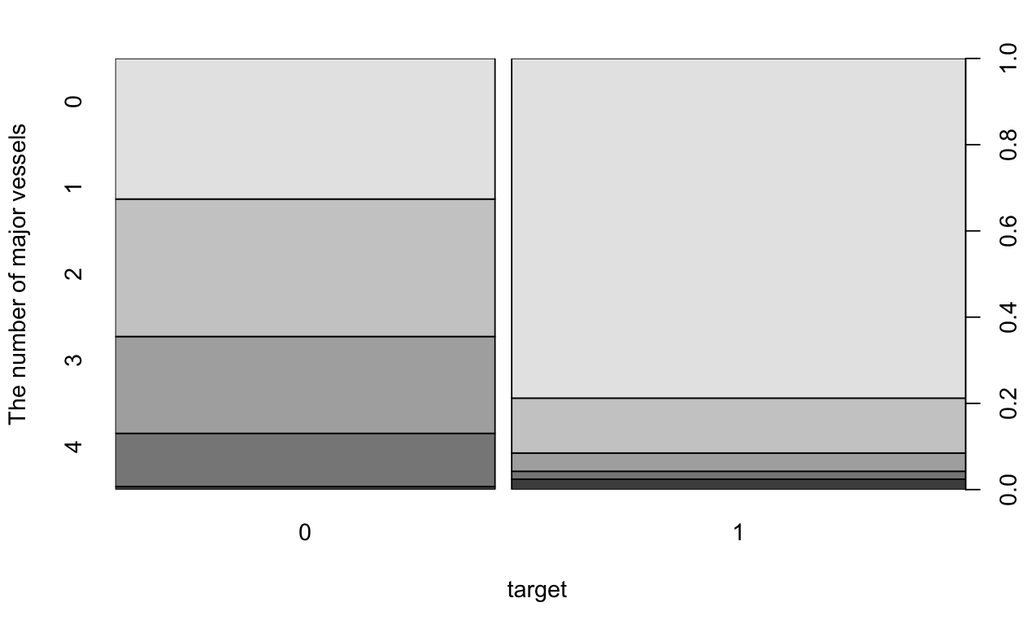

```r
plot(target,ca,
   xlab="target ", ylab="The number of major vessels", pch=19)
```

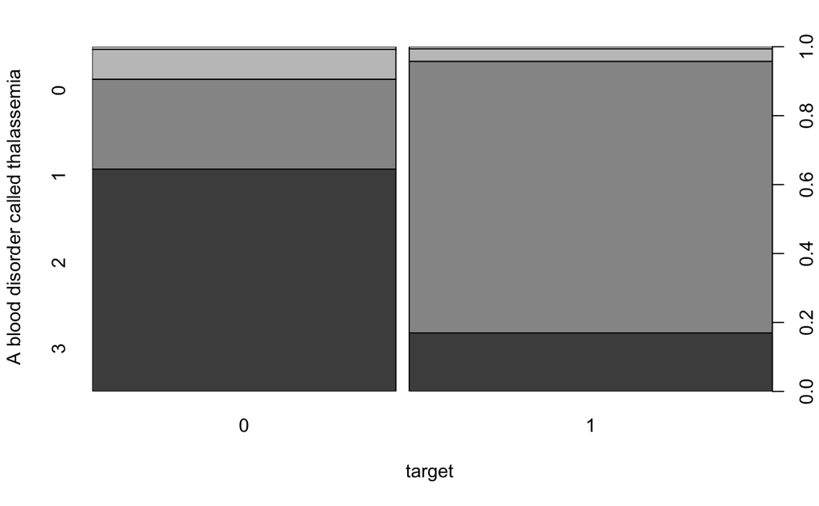

```r
plot(target,thal,
   xlab="target ", ylab=" A blood disorder called thalassemia", pch=19)
```

**Boxplot of all continuous variables**

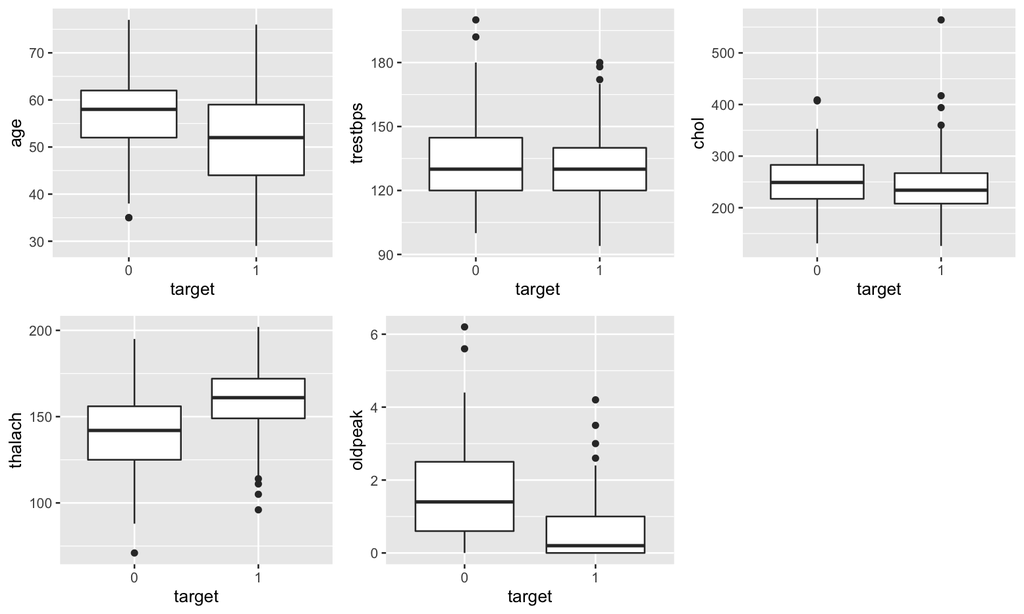

```r
plot.age <- ggplot(heart1, aes(x = target, y = age)) +
 geom_boxplot()

plot.trestbps <- ggplot(heart1, aes(x = target , y = trestbps)) +
 geom_boxplot()

plot.chol <- ggplot(heart1, aes(x = target, y = chol)) +
 geom_boxplot()

plot.thalach <- ggplot(heart1, aes(x = target , y = thalach)) +
 geom_boxplot()

plot.oldpeak <- ggplot(heart1, aes(x = target, y =oldpeak )) +
 geom_boxplot()


grid.arrange(plot.age, plot.trestbps, plot.chol, plot.thalach, plot.oldpeak, ncol=3, nrow=2)
```

Continous variables seem to have numerical stability, so we will not normalize them and we don’t always need to.

**Correlation Matrix**

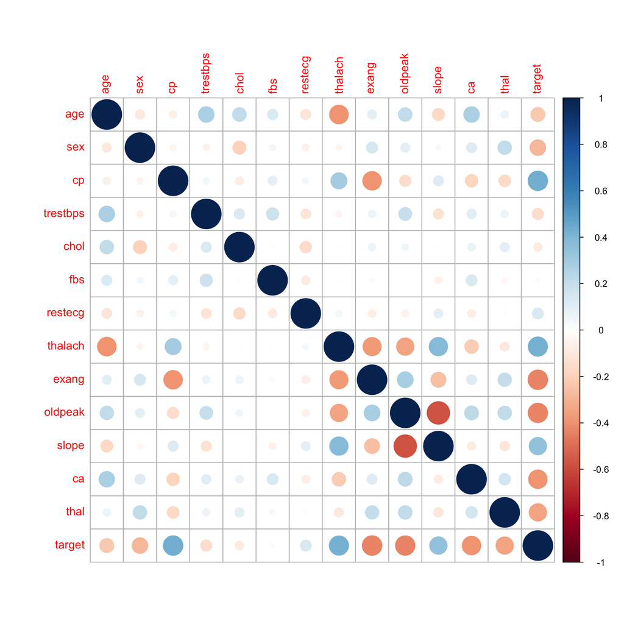

```r
#Displaying correlation matrix
Correlation <- cor(heart)
#Plotting Heart Map for correlation matrix
corrplot(Correlation, method = "circle")
```

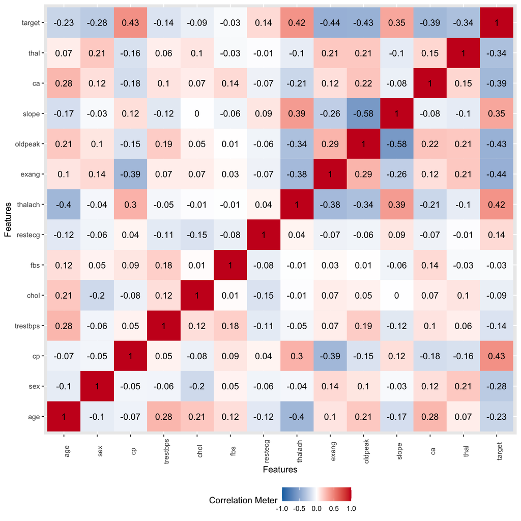

```r
plot_correlation(heart)
```

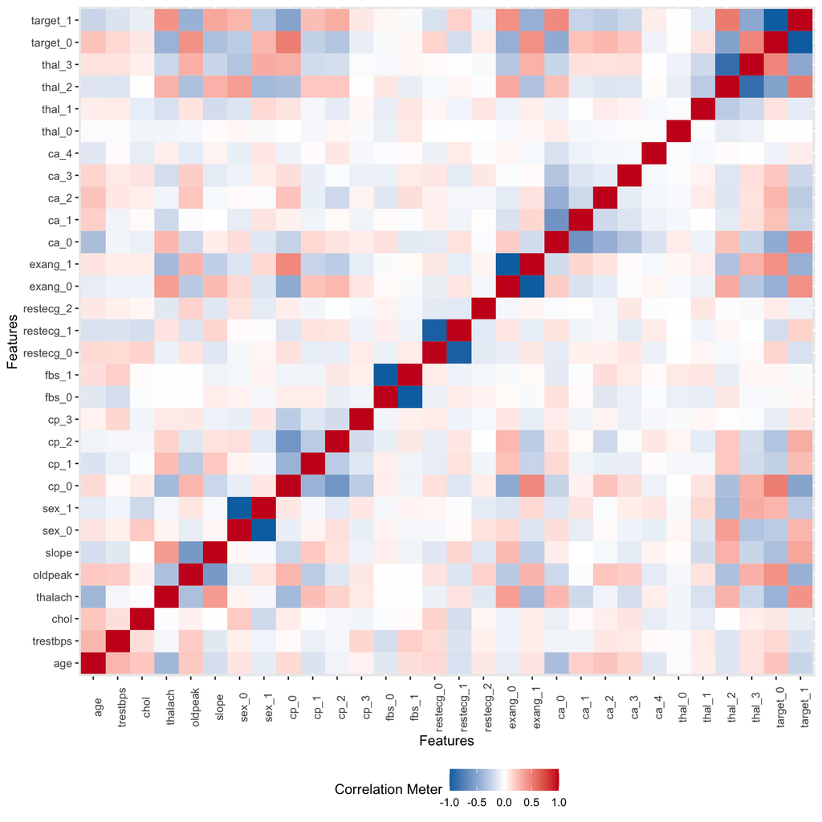

```r
plot_correlation(heart1)
```

We find that exercise-induced angia, chest pain type, ST depression induced by exercise relative to rest, and maximum heart rate achieved are the most strongly correlated with target.

Fasting blood sugar and cholesterol levels have no correlation.

There is a strong correlation between the following independent variables:

- slope and oldpeak
- The thalac, exang, oldpeak, and slope are all highly correlated, as are exang and cp and thalac.

**Presence and Absence of Heart-Disease**

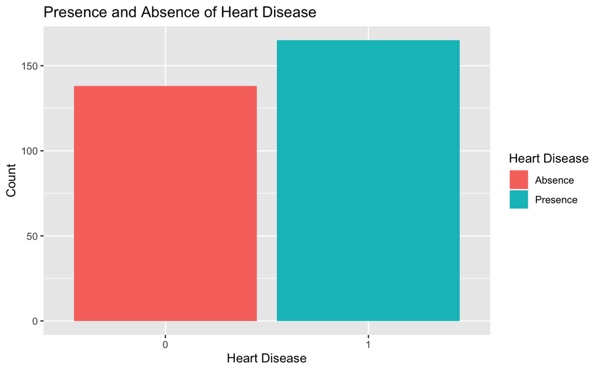

```r
# Bar plot for target (Heart disease)
heart1$target <- as.factor(heart1$target)
ggplot(heart1, aes(x=heart1$target, fill=heart1$target)) +
  geom_bar() +
  xlab("Heart Disease") +
  ylab("Count") +
  ggtitle("Presence and Absence of Heart Disease") +
  scale_fill_discrete(name = "Heart Disease", labels = c("Absence", "Presence"))
```

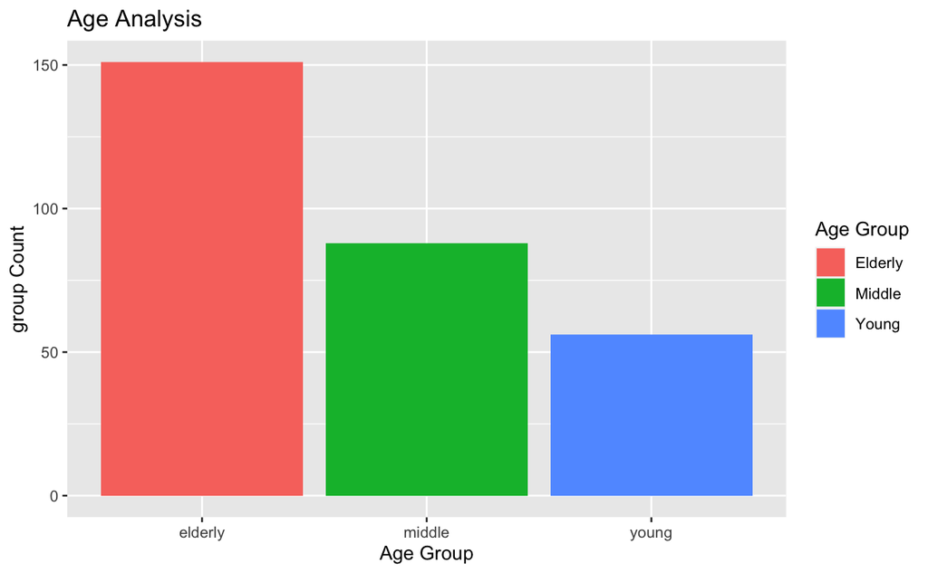

```r
# Group the different ages in three groups (young, middle, old)
young <- heart1[which((heart1$age<45)), ]
middle <- heart1[which((heart1$age>=45)&(heart1$age<55)), ]
elderly <- heart1[which(heart1$age>55), ]
groups <- data.frame(age_group = c("young","middle","elderly"), group_count = c(NROW(young$age), NROW(middle$age), NROW(elderly$age)))
#ploting different age groups
ggplot(groups, aes(x=groups$age_group, y=groups$group_count, fill=groups$age_group)) +
  ggtitle("Age Analysis") +
  xlab("Age Group")  +
  ylab("group Count") +
  geom_bar(stat="identity") +
  scale_fill_discrete(name = "Age Group", labels = c("Elderly", "Middle", "Young"))
```

**Occurance of Heart-disease based on Chest pain type**

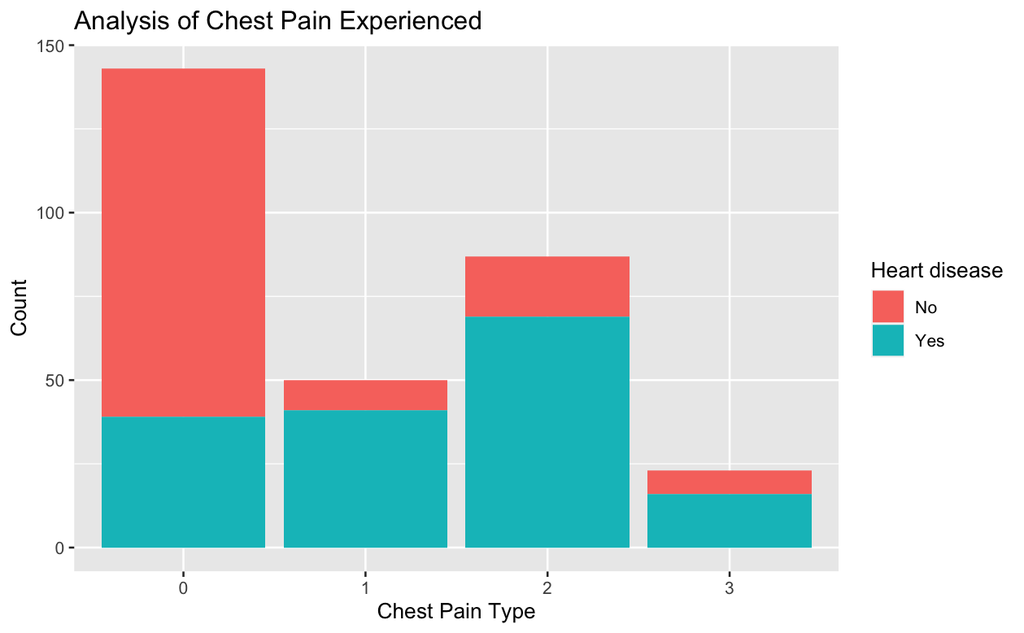

```r
# Bar plot for The chest pain ~ target
ggplot(heart1, aes(x= cp, fill=target)) +
geom_bar() +
xlab("Chest Pain Type") +
ylab("Count") +
ggtitle("Analysis of Chest Pain Experienced") +
scale_fill_discrete(name = "Heart disease", labels = c("No", "Yes"))
```

Now let us split the dataset to train dataset and test dataset

```r
#TestTrain split
set.seed(293)
trainIndex<-createDataPartition(y=heart1$target, p=0.7, list=FALSE)
trainFactor<-heart1[trainIndex,]
testFactor<-heart1[trainIndex,]

describe(trainFactor)
```

|  | vars | n | mean | sd | median | trimmed | mad | min | max | range | skew | kurtosis | se |
| --- | --- | --- | --- | --- | --- | --- | --- | --- | --- | --- | --- | --- | --- |
| age | 1 | 213 | 54.80 | 8.81 | 56.0 | 54.94 | 8.90 | 34 | 77.0 | 43.0 | -0.14 | -0.57 | 0.60 |
| sex* | 2 | 213 | 1.69 | 0.46 | 2.0 | 1.74 | 0.00 | 1 | 2.0 | 1.0 | -0.84 | -1.30 | 0.03 |
| cp* | 3 | 213 | 1.96 | 1.02 | 2.0 | 1.87 | 1.48 | 1 | 4.0 | 3.0 | 0.46 | -1.23 | 0.07 |
| trestbps | 4 | 213 | 132.43 | 17.24 | 130.0 | 131.32 | 14.83 | 94 | 192.0 | 98.0 | 0.65 | 0.55 | 1.18 |
| chol | 5 | 213 | 247.61 | 50.49 | 244.0 | 245.31 | 47.44 | 126 | 564.0 | 438.0 | 1.28 | 6.27 | 3.46 |
| fbs* | 6 | 213 | 1.15 | 0.35 | 1.0 | 1.06 | 0.00 | 1 | 2.0 | 1.0 | 2.00 | 1.99 | 0.02 |
| restecg* | 7 | 213 | 1.54 | 0.53 | 2.0 | 1.53 | 0.00 | 1 | 3.0 | 2.0 | 0.15 | -1.35 | 0.04 |
| thalach | 8 | 213 | 149.92 | 23.20 | 154.0 | 151.47 | 20.76 | 71 | 195.0 | 124.0 | -0.63 | 0.02 | 1.59 |
| exang* | 9 | 213 | 1.31 | 0.46 | 1.0 | 1.26 | 0.00 | 1 | 2.0 | 1.0 | 0.84 | -1.30 | 0.03 |
| oldpeak | 10 | 213 | 1.01 | 1.07 | 0.8 | 0.85 | 1.19 | 0 | 4.2 | 4.2 | 0.98 | 0.18 | 0.07 |

[output cut: 4 more lines]

```r
describe(testFactor)
```

|  | vars | n | mean | sd | median | trimmed | mad | min | max | range | skew | kurtosis | se |
| --- | --- | --- | --- | --- | --- | --- | --- | --- | --- | --- | --- | --- | --- |
| age | 1 | 213 | 54.80 | 8.81 | 56.0 | 54.94 | 8.90 | 34 | 77.0 | 43.0 | -0.14 | -0.57 | 0.60 |
| sex* | 2 | 213 | 1.69 | 0.46 | 2.0 | 1.74 | 0.00 | 1 | 2.0 | 1.0 | -0.84 | -1.30 | 0.03 |
| cp* | 3 | 213 | 1.96 | 1.02 | 2.0 | 1.87 | 1.48 | 1 | 4.0 | 3.0 | 0.46 | -1.23 | 0.07 |
| trestbps | 4 | 213 | 132.43 | 17.24 | 130.0 | 131.32 | 14.83 | 94 | 192.0 | 98.0 | 0.65 | 0.55 | 1.18 |
| chol | 5 | 213 | 247.61 | 50.49 | 244.0 | 245.31 | 47.44 | 126 | 564.0 | 438.0 | 1.28 | 6.27 | 3.46 |
| fbs* | 6 | 213 | 1.15 | 0.35 | 1.0 | 1.06 | 0.00 | 1 | 2.0 | 1.0 | 2.00 | 1.99 | 0.02 |
| restecg* | 7 | 213 | 1.54 | 0.53 | 2.0 | 1.53 | 0.00 | 1 | 3.0 | 2.0 | 0.15 | -1.35 | 0.04 |
| thalach | 8 | 213 | 149.92 | 23.20 | 154.0 | 151.47 | 20.76 | 71 | 195.0 | 124.0 | -0.63 | 0.02 | 1.59 |
| exang* | 9 | 213 | 1.31 | 0.46 | 1.0 | 1.26 | 0.00 | 1 | 2.0 | 1.0 | 0.84 | -1.30 | 0.03 |
| oldpeak | 10 | 213 | 1.01 | 1.07 | 0.8 | 0.85 | 1.19 | 0 | 4.2 | 4.2 | 0.98 | 0.18 | 0.07 |

[output cut: 4 more lines]

**Feature Selection**

Feature selection is an important step in model tuning. In a nutshell, it reduces dimensionality in a dataset which improves the speed and performance of a model.

The first step will be regression analysis, followed by VIF verification of multicollinearity. If the VIF is high, we will use PCA to generate a set of independent variables that explain the same amount as our original data but with less multicollinearity.

PCA, in essence, generates new variables that are linear functions of the original independent variables. So it’s analogous to f(g(x)), where g(x) generates a slew of variables that are functions of f. (x). In addition, for the regression, we are using a factor data set.

```r
vif(glm(target ~ age+sex+trestbps+chol+fbs+restecg+thalach+exang+oldpeak+slope+ca+thal, data=trainFactor, family="binomial"))
```

```
             GVIF Df GVIF^(1/(2*Df))
age      1.599266  1        1.264621
sex      1.620947  1        1.273164
trestbps 1.220009  1        1.104540
chol     1.230078  1        1.109089
fbs      1.187382  1        1.089671
restecg  1.289795  2        1.065688
thalach  1.455513  1        1.206446
exang    1.080376  1        1.039412
oldpeak  1.456269  1        1.206760
slope    1.501757  1        1.225462
ca       1.726626  4        1.070656
thal     1.471967  3        1.066554
```

# Logistic Regression model

```r
linearMod <- glm(target ~ ., data=trainFactor, family="binomial"(link="logit"))
summary(linearMod)
```

```
Call:
glm(formula = target ~ ., family = binomial(link = "logit"),
    data = trainFactor)

Deviance Residuals:
    Min       1Q   Median       3Q      Max
-2.9341  -0.2662   0.1273   0.5201   2.7620

Coefficients:
             Estimate Std. Error z value Pr(>|z|)
(Intercept) -0.391491   3.633200  -0.108 0.914191
age          0.008234   0.030775   0.268 0.789030
sex1        -1.806390   0.665790  -2.713 0.006665 **
cp1          0.715289   0.653533   1.094 0.273738
cp2          2.110020   0.611873   3.448 0.000564 ***
cp3          1.736616   0.801651   2.166 0.030288 *
trestbps    -0.032198   0.013534  -2.379 0.017360 *
chol        -0.002617   0.005021  -0.521 0.602166
fbs1         0.353928   0.648088   0.546 0.584989
restecg1     0.566937   0.477381   1.188 0.234992
restecg2    -0.069860   2.685919  -0.026 0.979250
thalach      0.025346   0.013637   1.859 0.063071 .
exang1      -0.605153   0.540643  -1.119 0.263003
oldpeak     -0.591934   0.289957  -2.041 0.041206 *
slope        0.788022   0.435629   1.809 0.070462 .
ca1         -1.651478   0.595966  -2.771 0.005587 **
ca2         -3.049442   0.958521  -3.181 0.001466 **
ca3         -1.828308   0.956856  -1.911 0.056037 .
ca4         -0.787205   2.577087  -0.305 0.760013
thal1        2.943355   2.457135   1.198 0.230964
thal2        2.109483   2.229824   0.946 0.344133
thal3        1.047385   2.258190   0.464 0.642779
---
Signif. codes:  0 ‘***’ 0.001 ‘**’ 0.01 ‘*’ 0.05 ‘.’ 0.1 ‘ ’ 1

(Dispersion parameter for binomial family taken to be 1)

    Null deviance: 293.58  on 212  degrees of freedom
Residual deviance: 135.08  on 191  degrees of freedom
AIC: 179.08

Number of Fisher Scoring iterations: 6
```

So it seems that the flouroscopy component is highly significant. According to this model, having 1-3 colored blood vessels and 0 colored blood vessels decreases the risk of the patient having heart attack. Let’s equate the model to the null model (just intercept)

```r
anova(linearMod, test="Chisq")
```

```
Analysis of Deviance Table

Model: binomial, link: logit

Response: target

Terms added sequentially (first to last)

         Df Deviance Resid. Df Resid. Dev  Pr(>Chi)
NULL                       212     293.58
age       1   16.509       211     277.07 4.841e-05 ***
sex       1   25.449       210     251.62 4.542e-07 ***
cp        3   51.502       207     200.12 3.823e-11 ***
trestbps  1    3.729       206     196.39 0.0534701 .
chol      1    0.728       205     195.66 0.3934620
fbs       1    0.000       204     195.66 0.9839245
restecg   2    1.622       202     194.04 0.4445216
thalach   1   10.315       201     183.73 0.0013196 **
exang     1    2.611       200     181.12 0.1061279
oldpeak   1   16.408       199     164.71 5.107e-05 ***
slope     1    1.753       198     162.96 0.1855438
ca        4   21.152       194     141.80 0.0002954 ***
thal      3    6.719       191     135.09 0.0814013 .
---
Signif. codes:  0 ‘***’ 0.001 ‘**’ 0.01 ‘*’ 0.05 ‘.’ 0.1 ‘ ’ 1
```

```r
library(pscl)
pR2(linearMod)
```

```
fitting null model for pseudo-r2
         llh      llhNull           G2     McFadden         r2ML         r2CU
 -67.5423755 -146.7918042  158.4988575    0.5398764    0.5248506    0.7016718
```

Logit accounts for about half of the variance in the formula (R2). The discrepancy between the null deviance and the residual deviance demonstrates how well our model does in comparison to the null model (a model with only the intercept). To determine the features to eliminate, we only hold those that, when applied, result in a significant decrease in residual deviance.

```r
summary(linearMod)
```

```
Call:
glm(formula = target ~ ., family = binomial(link = "logit"),
    data = trainFactor)

Deviance Residuals:
    Min       1Q   Median       3Q      Max
-2.9341  -0.2662   0.1273   0.5201   2.7620

Coefficients:
             Estimate Std. Error z value Pr(>|z|)
(Intercept) -0.391491   3.633200  -0.108 0.914191
age          0.008234   0.030775   0.268 0.789030
sex1        -1.806390   0.665790  -2.713 0.006665 **
cp1          0.715289   0.653533   1.094 0.273738
cp2          2.110020   0.611873   3.448 0.000564 ***
cp3          1.736616   0.801651   2.166 0.030288 *
trestbps    -0.032198   0.013534  -2.379 0.017360 *
chol        -0.002617   0.005021  -0.521 0.602166
fbs1         0.353928   0.648088   0.546 0.584989
restecg1     0.566937   0.477381   1.188 0.234992
restecg2    -0.069860   2.685919  -0.026 0.979250
thalach      0.025346   0.013637   1.859 0.063071 .
exang1      -0.605153   0.540643  -1.119 0.263003
oldpeak     -0.591934   0.289957  -2.041 0.041206 *
slope        0.788022   0.435629   1.809 0.070462 .
ca1         -1.651478   0.595966  -2.771 0.005587 **
ca2         -3.049442   0.958521  -3.181 0.001466 **
ca3         -1.828308   0.956856  -1.911 0.056037 .
ca4         -0.787205   2.577087  -0.305 0.760013
thal1        2.943355   2.457135   1.198 0.230964
thal2        2.109483   2.229824   0.946 0.344133
thal3        1.047385   2.258190   0.464 0.642779
---
Signif. codes:  0 ‘***’ 0.001 ‘**’ 0.01 ‘*’ 0.05 ‘.’ 0.1 ‘ ’ 1

(Dispersion parameter for binomial family taken to be 1)

    Null deviance: 293.58  on 212  degrees of freedom
Residual deviance: 135.08  on 191  degrees of freedom
AIC: 179.08

Number of Fisher Scoring iterations: 6
```

**Stepwise regression**

This is a variation on forward selection in which all candidate variables in the model are tested to see if their importance has been decreased below the given tolerance threshold after each step in which a variable is applied. If a variable is discovered to be insignificant, it is omitted from the model.

```r
linearMod.step <- step(linearMod)
```

```
Start:  AIC=179.08
target ~ age + sex + cp + trestbps + chol + fbs + restecg + thalach +
    exang + oldpeak + slope + ca + thal

           Df Deviance    AIC
- restecg   2   136.53 176.53
- age       1   135.16 177.16
- chol      1   135.35 177.35
- fbs       1   135.39 177.39
- exang     1   136.33 178.33
<none>          135.09 179.09
- thal      3   141.80 179.80
- slope     1   138.35 180.35
- thalach   1   138.84 180.84
- oldpeak   1   139.39 181.39
- trestbps  1   141.27 183.27
- sex       1   143.31 185.31
- cp        3   149.90 187.90
- ca        4   153.62 189.62

Step:  AIC=176.53
target ~ age + sex + cp + trestbps + chol + fbs + thalach + exang +
    oldpeak + slope + ca + thal

           Df Deviance    AIC
- age       1   136.53 174.53
- fbs       1   136.92 174.92
- chol      1   136.96 174.96
- exang     1   137.60 175.60
<none>          136.53 176.53
- thal      3   143.26 177.26
- slope     1   140.36 178.36
- thalach   1   140.43 178.43
- oldpeak   1   140.43 178.43
- trestbps  1   142.78 180.78
- sex       1   144.96 182.96
- cp        3   150.96 184.96
- ca        4   154.11 186.11

Step:  AIC=174.53
```

[output cut: 49 more lines]

```

Step:  AIC=170.4
target ~ sex + cp + trestbps + thalach + oldpeak + slope + ca +
    thal

           Df Deviance    AIC
<none>          138.40 170.40
- thal      3   145.19 171.19
- slope     1   142.49 172.49
- oldpeak   1   143.20 173.20
- thalach   1   143.45 173.45
- sex       1   145.85 175.85
- trestbps  1   145.88 175.88
- ca        4   158.22 182.22
- cp        3   158.91 184.91
```

A good model is the one that has minimum AIC among all the other models. Here the final model has a lower AIC value of 170.4 and hence indicates a better fit.

**Comparing Coefficients of Model1 and Model2(Step model)**

```r
car::compareCoefs(linearMod, linearMod.step, se = FALSE)
```

```
Calls:
1: glm(formula = target ~ ., family = binomial(link = "logit"), data = trainFactor)
2: glm(formula = target ~ sex + cp + trestbps + thalach + oldpeak + slope + ca + thal, family = binomial(link = "logit"), data = trainFactor)

             Model 1 Model 2
(Intercept)   -0.391  -0.818
age          0.00823
sex1           -1.81   -1.66
cp1            0.715   0.855
cp2             2.11    2.36
cp3             1.74    1.70
trestbps     -0.0322 -0.0323
chol        -0.00262
fbs1           0.354
restecg1       0.567
restecg2     -0.0699
thalach       0.0253  0.0266
exang1        -0.605
oldpeak       -0.592  -0.587
slope          0.788   0.853
ca1            -1.65   -1.65
ca2            -3.05   -2.72
ca3            -1.83   -1.80
ca4           -0.787  -0.887
thal1           2.94    2.88
thal2           2.11    2.00
thal3          1.047   0.961
```

```r
summary(linearMod.step)
```

```
Call:
glm(formula = target ~ sex + cp + trestbps + thalach + oldpeak +
    slope + ca + thal, family = binomial(link = "logit"), data = trainFactor)

Deviance Residuals:
    Min       1Q   Median       3Q      Max
-2.8908  -0.3467   0.1384   0.5095   2.7508

Coefficients:
            Estimate Std. Error z value Pr(>|z|)
(Intercept) -0.81789    3.22069  -0.254  0.79954
sex1        -1.65713    0.64017  -2.589  0.00964 **
cp1          0.85519    0.63042   1.357  0.17493
cp2          2.36368    0.57787   4.090 4.31e-05 ***
cp3          1.69813    0.77545   2.190  0.02853 *
trestbps    -0.03227    0.01234  -2.614  0.00894 **
thalach      0.02663    0.01255   2.121  0.03388 *
oldpeak     -0.58731    0.27460  -2.139  0.03246 *
slope        0.85313    0.42102   2.026  0.04273 *
ca1         -1.64801    0.56343  -2.925  0.00345 **
ca2         -2.72026    0.87106  -3.123  0.00179 **
ca3         -1.79938    0.93477  -1.925  0.05424 .
ca4         -0.88688    2.24158  -0.396  0.69236
thal1        2.88316    2.59344   1.112  0.26626
thal2        2.00444    2.39254   0.838  0.40215
thal3        0.96068    2.41914   0.397  0.69128
---
Signif. codes:  0 ‘***’ 0.001 ‘**’ 0.01 ‘*’ 0.05 ‘.’ 0.1 ‘ ’ 1

(Dispersion parameter for binomial family taken to be 1)

    Null deviance: 293.58  on 212  degrees of freedom
Residual deviance: 138.40  on 197  degrees of freedom
AIC: 170.4

Number of Fisher Scoring iterations: 6
```

# Cross-Validation of models linearMod and linearMod.step

```r
library(DAAG)
CVbinary(linearMod.step)
```

```
Fold:  2 5 6 1 10 8 3 4 9 7
Internal estimate of accuracy = 0.869
Cross-validation estimate of accuracy = 0.826
```

We see that the accuracy of the model built is 86% but the cross validation accuracy result is 82% which is fairly good. We have scope for improving the model for sure.

# ROC Curve

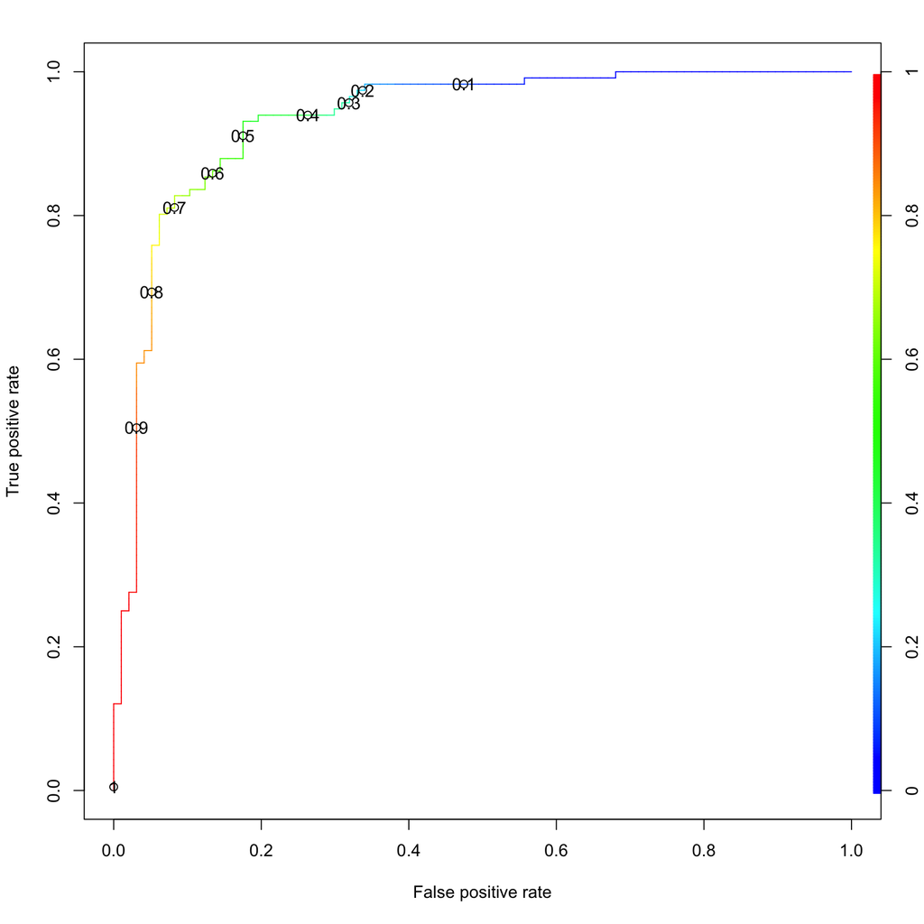

```r
#choosing the best cut-off probabillity value to the model
res <- predict(linearMod.step,type ="response")
ROCR_Pred <- prediction(res,trainFactor$target)
ROCR_perf <- performance(ROCR_Pred,"tpr","fpr")
plot(ROCR_perf,colorize=T,print.cutoffs.at =seq(0.1,by =0.1))
```

```r
#from the graph the cut-off value = 0.6.
```

# Residual Plots

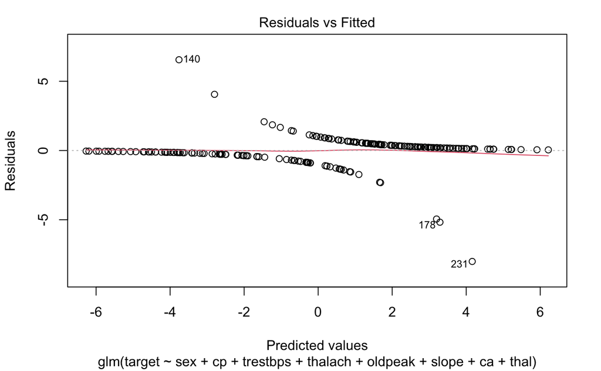

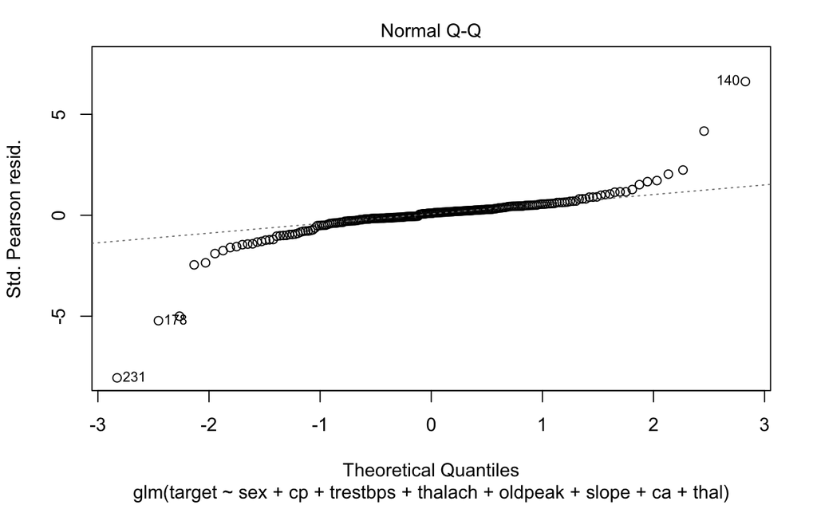

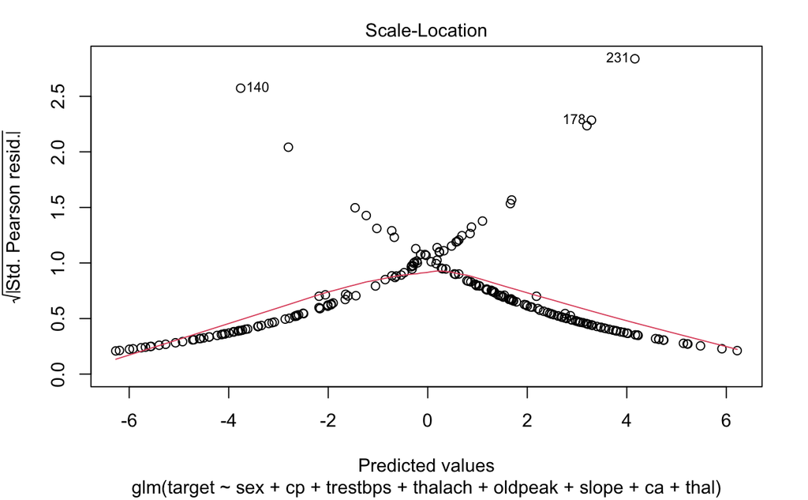

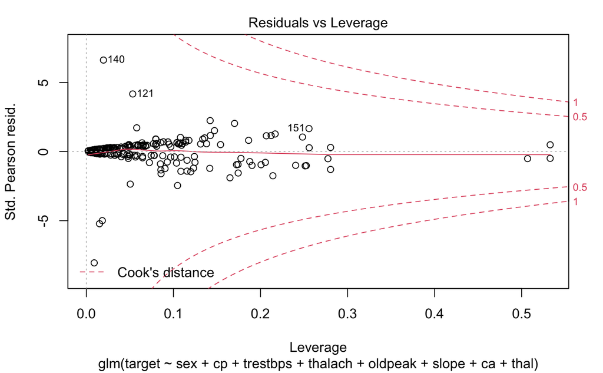

```r
plot(linearMod.step)
```

# Cooks Distance

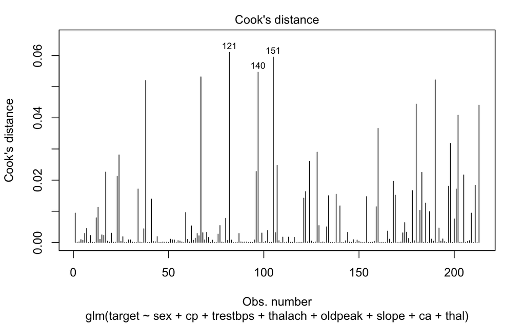

```r
#checking for the influential point
plot(linearMod.step,which=4,id.n =3)
```

```r
#the plot of cook_sd shows that 121 index haves higher cook_sd
#checking for the standarg residuals error
model.data <- augment(linearMod.step) %>% mutate(index =1:n())
model.data %>% top_n(3,.cooksd)
```

| .rownames | target | sex | cp | trestbps | thalach | oldpeak | slope | ca | thal | .fitted | .resid | .std.resid | .hat | .sigma | .cooksd | index |
| --- | --- | --- | --- | --- | --- | --- | --- | --- | --- | --- | --- | --- | --- | --- | --- | --- |
| 121 | 1 | 0 | 0 | 130 | 122 | 2.0 | 1 | 2 | 2 | -2.8007325 | 2.391536 | 2.457795 | 0.05319041 | 0.8217685 | 0.06102822 | 82 |
| 140 | 1 | 1 | 0 | 128 | 105 | 0.2 | 1 | 1 | 3 | -3.7604418 | 2.750799 | 2.778115 | 0.01956784 | 0.8165455 | 0.05466722 | 97 |
| 151 | 1 | 1 | 0 | 160 | 138 | 2.3 | 2 | 0 | 1 | -0.7238419 | 1.496115 | 1.734173 | 0.25570547 | 0.8311318 | 0.05949643 | 105 |

```r
#in these case the standard residuals error<3 so that can't be considered as a influential point
#checking for multi-collinearity
car::vif(linearMod.step)
```

```
             GVIF Df GVIF^(1/(2*Df))
sex      1.562091  1        1.249837
cp       1.571401  3        1.078238
trestbps 1.119746  1        1.058180
thalach  1.309554  1        1.144357
oldpeak  1.430157  1        1.195892
slope    1.352325  1        1.162895
ca       1.379795  4        1.041063
thal     1.548720  3        1.075628
```

```r
#no multi-collinearity presents
```

# Conclusion

Logistic Regression Model with variables like sex (sex), chest pain (cp), person’s resting blood pressure (trestbps) + person’s maximum heart rate(thalach), ST depression induced by exercise relative to rest (oldpeak), the slope of the peak exercise ST segment (slope), The number of major vessels (0-3) colored by flourosopy (ca), A blood disorder called thalassemia (thal) predicted an accuracy of 82% which is fairly a decent model for our prediction.